# Machine Learning: Entrenamiento Lasso

Jaime Ñíguez Baeza

A lo largo de este documento se va a exponer la preparación de los distintos modelos de aprendizaje supervisado Lasso y su validación frente a un conjunto de test independiente.

El algoritmo de selección de características Lasso se ha utilizado en base a la información contenida en:

- [Gareth James, Daniela Witten, Trevor Hastie, Robert Tibshirani. (2013). “An introduction to statistical learning : with applications in R”. New York :Springer. Descargado de https://www.statlearning.com/](https://www.statlearning.com/)
- [Friedman, J., Hastie, T., Tibshirani, R., Narasimhan, B., Tay, K., Simon, N., & Qian, J. (2024). “glmnet: Lasso and Elastic-Net Regularized Generalized Linear Models”. Recuperado de https://glmnet.stanford.edu](https://glmnet.stanford.edu/articles/glmnet.html)
- [Starmer, J. (2018), StatQuest. “Ridge, Lasso and Elastic-Net Regression in R”, YouTube. Recuperado de https://www.youtube.com/watch?v=ctmNq7FgbvI.](https://www.youtube.com/watch?v=ctmNq7FgbvI)

Las librerías utilizadas han sido:

```r
set.seed(12345)
library(dplyr)
library(caret)
library(glmnet)
library(ggplot2)
library(kableExtra)
```

# Preparación del conjunto de datos

Como se puede observar en la tabla ejemplo, estos datos incluyen además de los valores de expresión procesados y el diagnóstico Casos-Control (*Ca_Co_Last*) una serie de variables como *sex* y *age_at_baseline* que no serán incorporadas en este estudio.

```r
Genes = read.delim('CA_CO_LAST_sexo_edad_Normalized_Cleaned_PPMI_CIRCS.tsv')

kbl(Genes[c(1:6), c(1:10, 2174:2176)], row.names = FALSE) %>%
  kable_paper() %>%
  scroll_box(width = "100%", height = "200px")
```

| circAAGAB | circAARS1 | circAATF | circABCA13 | circABCA5 | circABCB10 | circABCB7 | circABCC1 | circABCC13 | circABCC4 | Ca_Co_Last | sex | age_at_baseline |
| --- | --- | --- | --- | --- | --- | --- | --- | --- | --- | --- | --- | --- |
| -0.1075195 | 2.9532896 | 1.855296 | 5.202926 | 2.9532896 | 5.202926 | 1.8552965 | 2.750246 | 2.750246 | 7.538008 | Case | Female | 62 |
| -0.1075195 | 3.2880880 | 1.855296 | 3.982021 | -0.1075195 | 4.070827 | 1.8552965 | 2.750246 | 1.855296 | 6.186749 | Case | Male | 60 |
| -0.1075195 | 3.1306007 | 2.224029 | 4.745466 | 1.3297687 | 3.676832 | -0.1075195 | 1.855296 | 1.329769 | 5.639206 | Case | Male | 64 |
| 2.2240287 | 1.8552965 | 1.329769 | 3.887345 | -0.1075195 | 4.233471 | 2.2240287 | 3.558666 | 1.329769 | 4.512139 | Control | Male | 60 |
| 1.3297687 | 2.9532896 | 2.512319 | 3.288088 | 1.3297687 | 3.676832 | -0.1075195 | 2.953290 | 1.329769 | 4.690585 | Control | Female | 70 |
| 1.3297687 | -0.1075195 | 1.329769 | 2.224029 | 1.3297687 | 2.750246 | 1.3297687 | 2.512319 | 1.329769 | 4.849323 | Case | Male | 65 |

En cuanto a la proporción de diagnósticos, esta se encuentra en 538 Casos y 320 Controles, por lo que la proporción de la clase mayoritaria (Casos) se establecería en 0.627 del total.

```r
table(Genes$Ca_Co_Last)
```

```
##
##    Case Control
##     538     320
```

```r
538/858
```

```
## [1] 0.6270396
```

El primer paso va a consistir en la división de estos datos en un conjunto de entrenamiento (*train*), que utilizaremos para elaborar los modelos predictivos y otro conjunto de validaciób (*test*), con el que evaluaremos el rendimiento predictivo.

Para estos modelos se utilizará una división 80%-20% de los datos para train y test respectivamente, además de la separación de los predictores y la variable respuesta en cada uno de ellos (conjuntos *x* para los predictores y conjuntos *y* para la respuesta).

Se eliminarán las variables que quedan fuera de nuestro estudio al realizar esta selección.

```r
train_i = createDataPartition(Genes$Ca_Co_Last,p=0.8,list=FALSE)
train = Genes[train_i,]
test = Genes[-train_i,]
x.train = subset(train, select = -c(Ca_Co_Last,sex,age_at_baseline))
y.train = subset(train, select = Ca_Co_Last)
x.test = subset(test, select = -c(Ca_Co_Last,sex,age_at_baseline))
y.test = subset(test, select = Ca_Co_Last)
y.train = ifelse(y.train == "Case",1,0)
y.test = ifelse(y.test == "Case",1,0)
```

# Modelo de regresión Lasso

A continuación se muestra el proceso realizado para el conjunto Lasso en el que no se balancearon las clases, por lo que considera el número original de muestras: 538 Casos: 320 Control.

## Ajuste del modelo

El ajuste del modelo comienza por la selección del mejor valor para el factor de penalización $\lambda$, el cual determinará lo estricta que resulte la regularización Lasso y por lo tanto qué predictores serán utilizados en el modelo final.

Esta selección se realiza mediante validación cruzada sobre el conjunto de entrenamiento, seleccionando el parámetro $\alpha$, el cual indica una regularización Lasso y como métrica a minimizar el Error Absoluto Medio (*mae*).

```r
Traindata_x_Mat <- data.matrix(x.train)
cvLassodata <- cv.glmnet(Traindata_x_Mat, y.train, alpha = 1, type.measure = "mae")

Lambda <- cvLassodata$lambda.min
Lambda
```

```
## [1] 0.01417837
```

```r
lasso.mod <- glmnet(x.train, y.train, alpha = 1,
     lambda = Lambda, family = "binomial")
lasso.mod
```

```
##
## Call:  glmnet(x = x.train, y = y.train, family = "binomial", alpha = 1,      lambda = Lambda)
##
##    Df  %Dev  Lambda
## 1 238 52.12 0.01418
```

## Validación

Para determinar si los predictores seleccionados portan información acerca del desarrollo del Parkinson, vamos a llevar a cabo un estudio de validación mediante el que se realizarán predicciones sobre el conjunto de test.

Posteriormente se generará la matriz de confusión entre las clases predichas y las reales y se establecerá el rendimiento del modelo, para el cual se valorará que posea una capacidad discriminativa general (*Accuracy*) entre las clases superior a la proporción de la clase mayoritaria, indicada mediante el *No Information Rate* (NIR)

```r
Testdata_x_Mat <- data.matrix(x.test)
predicciones <- as.data.frame(predict(lasso.mod, newx = Testdata_x_Mat, s = "lambda.min", type = "response"))

corte <- 0.5
# Clasifica las predicciones en clases (0 o 1).
clases_predichas <- ifelse(predicciones$s1 > corte, 1, 0)
predicciones$clase_pred <- clases_predichas

# Matriz de confusión.
Testdata_y_fact <- as.factor(y.test)
factorpred <- as.factor(predicciones$clase_pred)
confusion_matrix_Lasso <- caret::confusionMatrix(factorpred, Testdata_y_fact, positive = "1")
```

Se obtiene como resultado un valor de *Accuracy* de 0.6725, superior al NIR de 0.6257 con un $p-value$ que no permite asegurar que esta diferencia no se deba al azar. No obstante, consideraremos los predictores seleccionados de forma provisional en los siguientes análisis al ser este $p-value$ relativamente pequeño.

```r
confusion_matrix_Lasso
```

```
## Confusion Matrix and Statistics
##
##           Reference
## Prediction  0  1
##          0 28 20
##          1 36 87
##
##                Accuracy : 0.6725
##                  95% CI : (0.5967, 0.7422)
##     No Information Rate : 0.6257
##     P-Value [Acc > NIR] : 0.11738
##
##                   Kappa : 0.2638
##
##  Mcnemar's Test P-Value : 0.04502
##
##             Sensitivity : 0.8131
##             Specificity : 0.4375
##          Pos Pred Value : 0.7073
##          Neg Pred Value : 0.5833
##              Prevalence : 0.6257
##          Detection Rate : 0.5088
##    Detection Prevalence : 0.7193
##       Balanced Accuracy : 0.6253
##
##        'Positive' Class : 1
##
```

## Características seleccionadas

En este apartado vamos a generar un dataframe en el que se incluirán los predictores ordenados de forma descendente en base a su coeficiente.

Se muestran a continuación los predictores seleccionados y sus coeficientes

```r
# Extraigo los coeficientes del modelo:
coeficientes_lasso <- coef(lasso.mod, s = "lambda.min")

# Para poder seleccionar mejor cuales son distintos de 0 hago unos cambios en la estructura de los datos.
coef_vector <- as.vector(coeficientes_lasso)

# Identifico los índices de los elementos distintos de cero
indices <- which(coef_vector != 0)

# Creo un dataframe con los predictores
df_coeficientes_lasso <- as.data.frame(rownames(coeficientes_lasso))
colnames(df_coeficientes_lasso) <- "Predictores"

# Le añado los coeficientes correspondientes
df_coeficientes_lasso$Coeficientes <- coef_vector

# Filtro aquellos distintos de 0
predictoresLasso <- df_coeficientes_lasso[indices,]

# Ordeno por valor absoluto de coeficientes y elimino el intercepto.
predictoresLasso_Sort <- arrange(predictoresLasso, desc(abs(Coeficientes))) %>% filter(Predictores != "(Intercept)")

kbl(predictoresLasso_Sort, row.names = FALSE, format = "html", align = "c", centering = TRUE, booktabs = TRUE) %>%
  kable_paper() %>%
  scroll_box(width = "100%", height = "350px")
```

| Predictores | Coeficientes |
| --- | --- |
| circMFN2 | 0.2679364 |
| circCPT1A | -0.2626509 |
| circERBB2 | 0.2507463 |
| circNCF1C | 0.2356374 |
| circEDC3 | 0.2275681 |
| circRFC2 | 0.2079059 |
| circRUFY2 | -0.1975767 |
| circHERC2P9 | -0.1907982 |
| circRNPS1 | -0.1790926 |
| circTRAPPC8 | -0.1638791 |
| circMLYCD | 0.1571992 |
| circSON | -0.1564492 |
| circEXTL3 | 0.1535734 |
| circMPP5 | -0.1480958 |
| circMFN1 | 0.1439356 |
| circDDX50 | 0.1429521 |
| circMGRN1 | 0.1399368 |
| circTM9SF3 | -0.1385569 |
| circPFKP | 0.1358736 |
| circPAK2 | 0.1298198 |
| circCARD6 | -0.1296163 |
| circZSWIM6 | -0.1292492 |
| circEPDR1 | 0.1282799 |
| circRNASEH2B | -0.1275560 |
| circIL21R | -0.1271976 |
| circPLCL2 | -0.1225999 |
| circTPX2 | -0.1190778 |
| circNEAT1 | -0.1177573 |
| circDEPDC1 | -0.1176333 |
| circELK4 | -0.1162632 |

[output cut: 208 more lines]

# Modelos de regresión Lasso con balanceo de clases

En este apartado se van a generar modelos predictivos basado en Lasso a los que previamente se les habrá realizado un muestreo con el fin de equilibrar en gran medida el número de muestras pertenecientes a cada clase. Con esto se pretende reducir el sesgo que el modelo pudiera tener hacia la clase mayoritaria (*Case*), mejorando de esta manera el rendimiento al clasificar miembros de la clase minoritaria (*Control*).

Como paso previo vamos a generar dos subconjuntos dividiendo nuestros datos de entrenamiento según pertenezcan a la clase *Case* o *Control*.

Es importante no utilizar el conjunto original, ya que al realizar sobremuestreo vamos a multiplicar algunas muestras y en la posterior división en conjuntos de entrenamiento y test podrían acabar muestras iguales en ambos conjuntos, de manera que el rendimiento obtenido no sería válido.

```r
ClaseMayoritariadata <- subset(train, train$Ca_Co_Last == "Case")
ClaseMinoritariadata <- subset(train, train$Ca_Co_Last == "Control")
```

## Modelo de regresión Lasso con sobremuestreo de la clase minoritaria

### Ajuste del modelo

En primer lugar vamos a generar el modelo utilizando datos sobremuestreados de la clase minoritaria, de manera que se reduzca la diferencia entre ambas clases a la vez que no perdemos información por dejar algunas muestras sin utilizar.

Al generar el conjunto se utiliza el factor 0.8 en *size* que indica que la muestra será aproximadamente el 80% del tamaño de la clase mayoritaria, lo que se traduce en 431 miembros de la clase mayoritaria y 344 de la minoritaria.

Posteriormente se unen el conjunto sobremuestreado con el de la clase mayoritaria.

```r
oversampling <- ClaseMinoritariadata[sample(nrow(ClaseMinoritariadata), replace = TRUE, size = 0.8*nrow(ClaseMayoritariadata)), ]

# Combinar la clase mayoritaria submuestreada con la clase minoritaria
Train_oversampling_balanced <- rbind(ClaseMayoritariadata, oversampling)
table(Train_oversampling_balanced$Ca_Co_Last)
```

```
##
##    Case Control
##     431     344
```

A continuación se separa el vector que contiene la variable respuesta y se calcula el valor de $\lambda$, que a diferencia del caso anterior, utiliza la métrica *Deviance* a la hora de escoger el mejor valor. Este cambio se realizó ya que se observó que los resultados predictivos mejoraban con el cambio de métrica.

En este caso el valor de $\lambda$ obtenido es de *0.01291431*, ligeramente inferior al obtenido en el modelo Lasso sin sobremuestreo, por lo que la regularización será menos estricta.

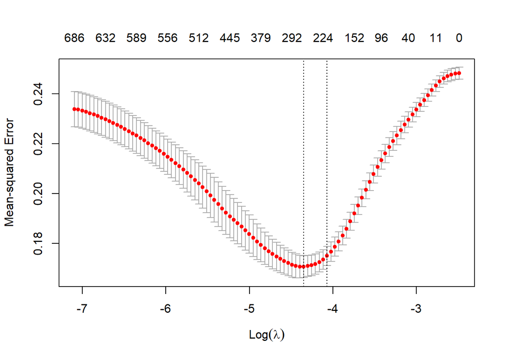

```r
# Separamos los predictores y la respuesta en el conjunto de train.

Traindata_x = subset(Train_oversampling_balanced, select = -c(Ca_Co_Last,sex,age_at_baseline))
Traindata_y <- subset(Train_oversampling_balanced, select = Ca_Co_Last)
Traindata_y <- ifelse(Traindata_y == "Control", 0, 1)

# Generar mejor valor de lambda mediante validación cruzada:
Traindata_x_Mat <- data.matrix(Traindata_x)
cvLassodata <- cv.glmnet(Traindata_x_Mat, Traindata_y, type.measure = "deviance")
plot(cvLassodata)
```

```r
Lambda <- cvLassodata$lambda.min
Lambda
```

```
## [1] 0.01291431
```

Utilizando este valor de $\lambda$ ajustamos el entrenamiento del modelo, el cual contendrá 240 predictores tal y como se muestra.

```r
lasso.mod.OverS <- glmnet(Traindata_x, Traindata_y, alpha = 1,
    lambda = Lambda, family = "binomial")
lasso.mod.OverS
```

```
##
## Call:  glmnet(x = Traindata_x, y = Traindata_y, family = "binomial",      alpha = 1, lambda = Lambda)
##
##    Df  %Dev  Lambda
## 1 240 64.48 0.01291
```

### Validación

La validación frente al conjunto de test se lleva a cabo de la misma manera que en el caso anterior. Los resultados obtenidos en este caso son muy similares, por lo que aplicando el mismo criterio, los predictores seleccionados serán considerados en siguientes análisis.

```r
Testdata_x_Mat <- data.matrix(x.test)
predicciones <- as.data.frame(predict(lasso.mod.OverS, newx = Testdata_x_Mat, s = "lambda.min", type = "response"))

corte <- 0.5
# Clasifica las predicciones en clases (0 o 1).
clases_predichas <- ifelse(predicciones$s1 > corte, 1, 0)
predicciones$clase_pred <- clases_predichas

# Matriz de confusión.
Testdata_y_fact <- as.factor(y.test)
factorpred <- as.factor(predicciones$clase_pred)

confusion_matrix_OverS <- caret::confusionMatrix(factorpred, Testdata_y_fact, positive = "1")
confusion_matrix_OverS
```

```
## Confusion Matrix and Statistics
##
##           Reference
## Prediction  0  1
##          0 24 17
##          1 40 90
##
##                Accuracy : 0.6667
##                  95% CI : (0.5907, 0.7368)
##     No Information Rate : 0.6257
##     P-Value [Acc > NIR] : 0.152070
##
##                   Kappa : 0.2329
##
##  Mcnemar's Test P-Value : 0.003569
##
##             Sensitivity : 0.8411
##             Specificity : 0.3750
##          Pos Pred Value : 0.6923
##          Neg Pred Value : 0.5854
##              Prevalence : 0.6257
##          Detection Rate : 0.5263
##    Detection Prevalence : 0.7602
##       Balanced Accuracy : 0.6081
##
##        'Positive' Class : 1
##
```

### Características seleccionadas

En cuanto a los predictores seleccionados, se les aplicará el mismo tratamiento que anteriormente.

```r
# Extraigo los coeficientes:
coeficientes_lasso <- coef(lasso.mod.OverS, s = "lambda.min")

# Para poder seleccionar mejor cuales son distintos de 0 hago unos cambios en la estructura de los datos a vector
coef_vector <- as.vector(coeficientes_lasso)

# Identifico los índices de los elementos distintos de cero
indices <- which(coef_vector != 0)

# Creo un dataframe con los predictores
df_coeficientes_lasso <- as.data.frame(rownames(coeficientes_lasso))
colnames(df_coeficientes_lasso) <- "Predictores"

# Le añado los coeficientes correspondientes
df_coeficientes_lasso$coeficientes <- coef_vector

# Filtro aquellos distintos de 0
predictoresLasso.over <- df_coeficientes_lasso[indices,]

# Ordeno por valor absoluto de coeficientes y elimino el intercepto.
predictoresLasso.over <- arrange(predictoresLasso.over, desc(abs(coeficientes))) %>% filter(Predictores != "(Intercept)")

kbl(predictoresLasso.over, row.names = FALSE, format = "html", align = "c", centering = TRUE, booktabs = TRUE) %>%
  kable_paper() %>%
  scroll_box(width = "100%", height = "350px")
```

| Predictores | coeficientes |
| --- | --- |
| circFAM120B | -0.3221995 |
| circREPS2 | 0.3056394 |
| circCPT1A | -0.2937163 |
| circCATSPERG | 0.2710762 |
| circEDC3 | 0.2621675 |
| circRFC2 | 0.2375609 |
| circPLCL2 | -0.2158144 |
| circEXTL3 | 0.2011833 |
| circDDX50 | 0.1951612 |
| circRALGAPA1 | -0.1871876 |
| circANKRD17 | -0.1814777 |
| circTRABD2A | -0.1810423 |
| circSLC24A4 | -0.1802810 |
| circRIC8B | 0.1760425 |
| circNSD1 | -0.1759755 |
| circSON | -0.1736721 |
| circIL21R | -0.1695711 |
| circTBC1D2B | 0.1678682 |
| circCRY1 | -0.1662564 |
| circFTO | 0.1652804 |
| circMDGA1 | -0.1650775 |
| circDCUN1D1 | 0.1644169 |
| circTLK2 | -0.1641776 |
| circLIX1.AS1 | -0.1559478 |
| circHSPA14 | 0.1546614 |
| circPAK2 | 0.1524617 |
| circMBP | -0.1505975 |
| circMLYCD | 0.1488373 |
| circHACD1 | -0.1468031 |
| circARL6IP6 | -0.1432176 |

[output cut: 210 more lines]

## Modelo de regresión Lasso con submuestreo de la clase mayoritaria

### Ajuste del modelo

Por último para los modelos basados en Lasso, se va a llevar a cabo un submuestreo de la clase mayoritaria, de manera que su número se equilibre en gran medida respecto al número de muestras de la clase minoritaria. En concreto se reducirá esta diferencia de manera que la clase mayoritaria solo contenga un 25% más de muestras.

Tras esto se calcula el valor de $\lambda$, obteniéndose 0.01872194, lo que indica una regularización Lasso más estricta que generará un modelo con menos predictores.

```r
undersampling <- ClaseMayoritariadata[sample(nrow(ClaseMayoritariadata), replace = TRUE, size = 1.25*nrow(ClaseMinoritariadata)), ]

# Combinar la clase mayoritaria submuestreada con la clase minoritaria
Train_Undersampling_balanced <- rbind(ClaseMinoritariadata, undersampling)
table(Train_Undersampling_balanced$Ca_Co_Last)
```

```
##
##    Case Control
##     320     256
```

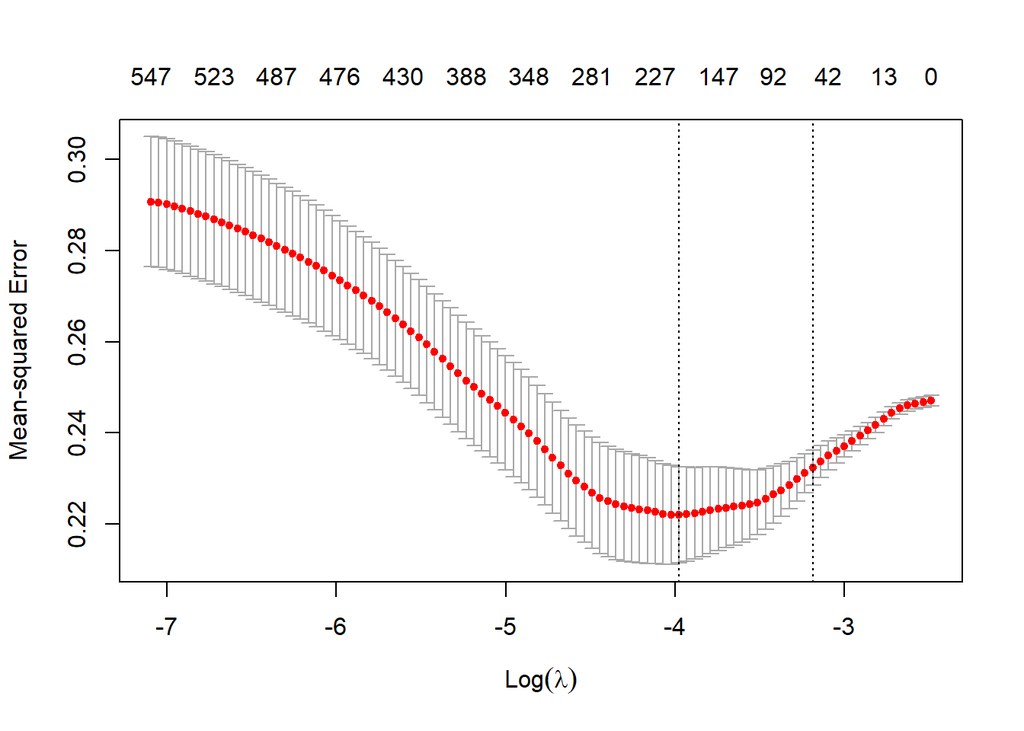

```r
# Separamos los predictores y la respuesta en el conjunto de train.
Traindata_x = subset(Train_Undersampling_balanced, select = -c(Ca_Co_Last,sex,age_at_baseline))
Traindata_y <- subset(Train_Undersampling_balanced, select = Ca_Co_Last)
Traindata_y <- ifelse(Traindata_y == "Control", 0, 1)

# Generar mejor valor de lambda mediante validación cruzada:
Traindata_x_Mat <- data.matrix(Traindata_x)
cvLassodata <- cv.glmnet(Traindata_x_Mat, Traindata_y, type.measure = "deviance")
plot(cvLassodata)
```

```r
Lambda <- cvLassodata$lambda.min
Lambda
```

```
## [1] 0.01872194
```

El modelo resultante contiene un total de 181 predictores.

```r
lasso.mod.UnderS <- glmnet(Traindata_x, Traindata_y, alpha = 1,
    lambda = Lambda, family = "binomial")
lasso.mod.UnderS
```

```
##
## Call:  glmnet(x = Traindata_x, y = Traindata_y, family = "binomial",      alpha = 1, lambda = Lambda)
##
##    Df %Dev  Lambda
## 1 181 53.7 0.01872
```

### Validación

En cuanto a su rendimiento, el modelo Lasso con submuestreo presenta los peores resultados, ya que su capacidad predictiva queda por debajo del NIR. Por este motivo, los predictores no serán utilizados en posteriores análisis.

```r
Testdata_x_Mat <- data.matrix(x.test)
predicciones <- as.data.frame(predict(lasso.mod.UnderS, newx = Testdata_x_Mat, s = "lambda.min", type = "response"))

corte <- 0.5
# Clasifica las predicciones en clases (0 o 1).
clases_predichas <- ifelse(predicciones$s1 > corte, 1, 0)
predicciones$clase_pred <- clases_predichas

# Matriz de confusión.

factorpred <- as.factor(predicciones$clase_pred)

confusion_matrix_UnderS <- caret::confusionMatrix(factorpred, Testdata_y_fact, positive = "1")
confusion_matrix_UnderS
```

```
## Confusion Matrix and Statistics
##
##           Reference
## Prediction  0  1
##          0 36 41
##          1 28 66
##
##                Accuracy : 0.5965
##                  95% CI : (0.5189, 0.6707)
##     No Information Rate : 0.6257
##     P-Value [Acc > NIR] : 0.8080
##
##                   Kappa : 0.1723
##
##  Mcnemar's Test P-Value : 0.1486
##
##             Sensitivity : 0.6168
##             Specificity : 0.5625
##          Pos Pred Value : 0.7021
##          Neg Pred Value : 0.4675
##              Prevalence : 0.6257
##          Detection Rate : 0.3860
##    Detection Prevalence : 0.5497
##       Balanced Accuracy : 0.5897
##
##        'Positive' Class : 1
##
```

### Características seleccionadas

En este caso también se van a extraer las características seleccionadas por el modelo con el fin de compararlas con las que obtuvieron los modelos más exitosos.

```r
# Creo un dataframe con los predictores
df_coeficientes_lasso <- as.data.frame(rownames(coeficientes_lasso))
colnames(df_coeficientes_lasso) <- "Predictores"

# Le añado los coeficientes correspondientes
df_coeficientes_lasso$Coeficientes <- coef_vector

# Filtro aquellos distintos de 0
predictoresLasso <- df_coeficientes_lasso[indices,]


# Extraigo los coeficientes:
coeficientes_lassoUnder <- coef(lasso.mod.UnderS, s = "lambda.min")

# Para poder seleccionar mejor cuales son distintos de 0 hago unos cambios en la estructura de los datos.
coef_vector <- as.vector(coeficientes_lassoUnder)

# Identifico los índices de los elementos distintos de cero
indices <- which(coef_vector != 0)

# Creo un dataframe con los predictores
df_coeficientes_lassoUnder <- as.data.frame(rownames(coeficientes_lassoUnder))
colnames(df_coeficientes_lassoUnder) <- "Predictores"

# Le añado los coeficientes correspondientes
df_coeficientes_lassoUnder$Coeficientes <- coef_vector

# Filtro aquellos distintos de 0

predictoresLasso.under <- df_coeficientes_lassoUnder[indices,]

predictoresLasso.under <- arrange(predictoresLasso.under, desc(abs(Coeficientes))) %>%
  filter(Predictores != "(Intercept)")

kbl(predictoresLasso.under) %>%
  kable_paper() %>%
  scroll_box(width = "100%", height = "200px")
```

| Predictores | Coeficientes |
| --- | --- |
| circNCF1C | 0.3132510 |
| circMFN2 | 0.2995963 |
| circTRAPPC8 | -0.2620990 |
| circRFC2 | 0.2614760 |
| circAPOOL | 0.2459266 |
| circERBB2 | 0.2378321 |
| circINTS7 | 0.1839261 |
| circKDM1A | -0.1652175 |
| circEPDR1 | 0.1608623 |
| circNEAT1 | -0.1553767 |
| circMPP5 | -0.1546017 |
| circTRABD2A | -0.1486395 |
| circITPA | -0.1452878 |
| circCOG5 | -0.1403627 |
| circPFKP | 0.1395500 |
| circRIC8B | 0.1390035 |
| circCPT1A | -0.1363585 |
| circGIN1 | 0.1345511 |
| circCARD6 | -0.1342126 |
| circSLC39A8 | -0.1302688 |
| circATF7IP | 0.1287337 |
| circNIPAL3 | 0.1285367 |
| circTPX2 | -0.1260483 |
| circMDGA1 | -0.1257448 |
| circLIX1.AS1 | -0.1245393 |
| circHDAC9 | -0.1234548 |
| circGYG2P1 | 0.1228126 |
| circMLYCD | 0.1192679 |
| circHERC2P9 | -0.1187735 |
| circMGRN1 | 0.1149741 |

[output cut: 151 more lines]

# Comparación del rendimiento entre modelos

Para almacenar los resultados de rendimiento de los modelos y compararlos más adelante se va a generar un dataframe con las métricas calculadas en la matriz de confusión. También se añadirá el número de predictores

```r
Lasso <- data.frame(t(c(confusion_matrix_Lasso$byClass, confusion_matrix_Lasso$overall, "N.Pred" = nrow(predictoresLasso_Sort))), row.names = "Lasso")
Lasso.OverS <- data.frame(t(c(confusion_matrix_OverS$byClass, confusion_matrix_OverS$overall, "N.Pred" = nrow(predictoresLasso.over))), row.names = "Lasso.OverS")
Lasso.UnderS <- data.frame(t(c(confusion_matrix_UnderS$byClass, confusion_matrix_UnderS$overall, "N.Pred" = nrow(predictoresLasso.under))), row.names = "Lasso.UnderS")

MatConfLassoDF <- rbind(Lasso, Lasso.OverS, Lasso.UnderS)


kbl(MatConfLassoDF) %>%
  kable_paper() %>%
  scroll_box(width = "100%", height = "200px")
```

|  | Sensitivity | Specificity | Pos.Pred.Value | Neg.Pred.Value | Precision | Recall | F1 | Prevalence | Detection.Rate | Detection.Prevalence | Balanced.Accuracy | Accuracy | Kappa | AccuracyLower | AccuracyUpper | AccuracyNull | AccuracyPValue | McnemarPValue | N.Pred |
| --- | --- | --- | --- | --- | --- | --- | --- | --- | --- | --- | --- | --- | --- | --- | --- | --- | --- | --- | --- |
| Lasso | 0.8130841 | 0.4375 | 0.7073171 | 0.5833333 | 0.7073171 | 0.8130841 | 0.7565217 | 0.625731 | 0.5087719 | 0.7192982 | 0.6252921 | 0.6725146 | 0.2638376 | 0.5967099 | 0.7422179 | 0.625731 | 0.1173751 | 0.0450209 | 238 |
| Lasso.OverS | 0.8411215 | 0.3750 | 0.6923077 | 0.5853659 | 0.6923077 | 0.8411215 | 0.7594937 | 0.625731 | 0.5263158 | 0.7602339 | 0.6080607 | 0.6666667 | 0.2329425 | 0.5906547 | 0.7367853 | 0.625731 | 0.1520701 | 0.0035686 | 240 |
| Lasso.UnderS | 0.6168224 | 0.5625 | 0.7021277 | 0.4675325 | 0.7021277 | 0.6168224 | 0.6567164 | 0.625731 | 0.3859649 | 0.5497076 | 0.5896612 | 0.5964912 | 0.1722904 | 0.5188887 | 0.6706884 | 0.625731 | 0.8080352 | 0.1485618 | 181 |